# A (very) short introduction to R and RStudio

## What is R?

- Open-source statistical software
- Computational environment and programming language
- Tool for statistical analysis and data visualization

## SPSS vs R

- SPSS:  
  Easy to use (point-and-click)  
  Basic graphics  
  Limited statistical procedures  
  Inflexible programming
- R:  
  More difficult to use (syntax-based)  
  Professional graphics  
  Unlimited statistical procedures  
  Flexible programming

## Getting and instaling R and RStudio

R and RStudio are available for free download:  
1. Download R: http://cran.r-project.org/  
2. Download RStudio: http://www.rstudio.org/

R and RStudio are compatible with the main OS’s:  
- PC  
- MAC  
- Linux

## R environment

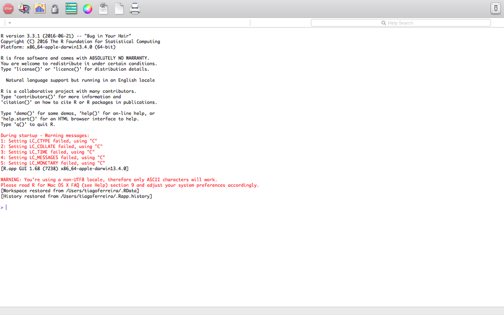

## R basic features

The R basic installation includes a set of resources that allows:  
- Creating different types of data structures  
- Editing and managing data structures  
- Analyzing data  
- Data visualization

*R base functionalities can easily be expanded through the installation of packages developed by a large, dynamic community of contributors. These packages are available for free download on [CRAN](https://www.r-project.org/).*

## Reasons for using RStudio:

RStudio is an Integrated Development Environment (IDE) that makes R’s use much easier:

- Makes it easier to write scripts (code completion)
- Provides integrated support for editing and executing R code
- Gives access to several functionalities through graphical interface (e.g., set work directory)
- Allows creating and sharing R projects
- Makes graphics and other outputs much more accessible
- Includes a notebook interface (RMarkdown) to produce high-quality documents, reports, presentations, and dashboards
- [and much more…](https://www.r-bloggers.com/top-6-reasons-you-need-to-be-using-rstudio/)

## The RStudio Integrated Development Environment (IDE)

[figure not shown]